# sizeMat: An R Package to Estimate Size at Sexual Maturity

Josymar Torrejon-Magallanes

2026-05-29

# Introduction

The `sizeMat` package estimates size at sexual maturity in organisms, especially fish and invertebrates.

It includes tools for estimating:

- size at morphometric maturity, based on relative growth and classification of individuals into juvenile and adult groups;
- size at gonadal maturity, based on maturity stages;
- maturity ogives using frequentist or Bayesian logistic regression;
- uncertainty around model parameters and size at 50% maturity, usually denoted as $L_{50}$.

The size at sexual maturity is defined here as the length at which a randomly chosen individual has a 50% probability of being mature.

# Installation

The stable version can be installed from CRAN:

```r
install.packages("sizeMat")
```

The development version can be installed from GitHub:

```r
# install.packages("devtools")
devtools::install_github("ejosymart/sizeMat")
```

# 1. Size at morphometric maturity

Morphometric maturity is estimated from the relative growth relationship between two allometric variables.

In this example, we use the `crabdata` dataset. This dataset contains allometric measurements and biological information for crabs of the species *Chionoecetes tanneri*.

```r
data(crabdata)

head(crabdata)
```

```
#>   year month carapace_width carapace_length chela_height chela_width
#> 1 1974     1            106             107         14.0          22
#> 2 1974     1            129             129         27.0          44
#> 3 1974     1            119             122         14.6          23
#> 4 1974     1            115             118         18.6          29
#> 5 1974     1             97              97         11.0          17
#> 6 1974     1             94              96         10.0          15
#>   sex_category
#> 1            m
#> 2            m
#> 3            m
#> 4            m
#> 5            m
#> 6            m
```

```r
names(crabdata)
```

```
#> [1] "year"            "month"           "carapace_width"  "carapace_length"
#> [5] "chela_height"    "chela_width"     "sex_category"
```

## 1.1 Classification of juveniles and adults

The function `classify_mature()` classifies individuals into two groups:

- juveniles = 0
- adults = 1

The classification is based on a principal components analysis using two allometric variables, followed by hierarchical clustering and discriminant analysis.

The argument `varNames` requires two allometric variables. The first variable is treated as the independent variable and the second as the dependent variable. The argument `varSex` identifies the sex variable. If `selectSex = NULL`, all individuals are used.

```r
classify_data <- classify_mature(
  crabdata,
  varNames = c("carapace_width", "chela_height"),
  varSex = "sex_category",
  selectSex = NULL,
  method = "ld"
)
```

```
#> all individuals were used in the analysis
```

```r
classify_data_males <- classify_mature(
  crabdata,
  varNames = c("carapace_width", "chela_height"),
  varSex = "sex_category",
  selectSex = "m",
  method = "ld"
)
```

```
#> only m-sex were used in the analysis
```

```r
print(classify_data)
```

```
#> Number in juvenile group = 83
#>
#> Number in adult group = 140
#>
#> --------------------------------------------------------
#> 1) Linear regression for juveniles
#>
#> Call:
#> glm(formula = y ~ x, data = juv)
#>
#> Coefficients:
#>              Estimate Std. Error t value Pr(>|t|)
#> (Intercept) -3.794687   0.497056  -7.634 3.93e-11 ***
#> x            0.161327   0.004701  34.314  < 2e-16 ***
#> ---
#> Signif. codes:  0 '***' 0.001 '**' 0.01 '*' 0.05 '.' 0.1 ' ' 1
#>
#> (Dispersion parameter for gaussian family taken to be 0.7320842)
#>
#>     Null deviance: 921.306  on 82  degrees of freedom
#> Residual deviance:  59.299  on 81  degrees of freedom
#> AIC: 213.63
#>
#> Number of Fisher Scoring iterations: 2
#>
#> --------------------------------------------------------
#> 2) Linear regression for adults
#>
#> Call:
#> glm(formula = y ~ x, data = adt)
#>
#> Coefficients:
#>               Estimate Std. Error t value Pr(>|t|)
#> (Intercept) -11.246726   1.199496  -9.376   <2e-16 ***
#> x             0.273837   0.008648  31.663   <2e-16 ***
#> ---
#> Signif. codes:  0 '***' 0.001 '**' 0.01 '*' 0.05 '.' 0.1 ' ' 1
#>
#> (Dispersion parameter for gaussian family taken to be 2.265729)
#>
#>     Null deviance: 2584.24  on 139  degrees of freedom
#> Residual deviance:  312.67  on 138  degrees of freedom
#> AIC: 515.79
#>
#> Number of Fisher Scoring iterations: 2
#>
#> --------------------------------------------------------
#> 3) Difference between slopes (ANCOVA)
#>               Estimate  Std. Error   t value     Pr(>|t|)
#> (Intercept) -3.7946869 0.757105677 -5.012097 1.109526e-06
#> x            0.1613275 0.007161179 22.528064 6.035478e-59
#> mature      -7.4520389 1.285219562 -5.798261 2.320729e-08
#> x:mature     0.1125093 0.010361046 10.858878 2.956242e-22
#> [1] "slopes are different"
```

## 1.2 Base graphics plot for classified data

By default, `plot.classify()` uses base R graphics.

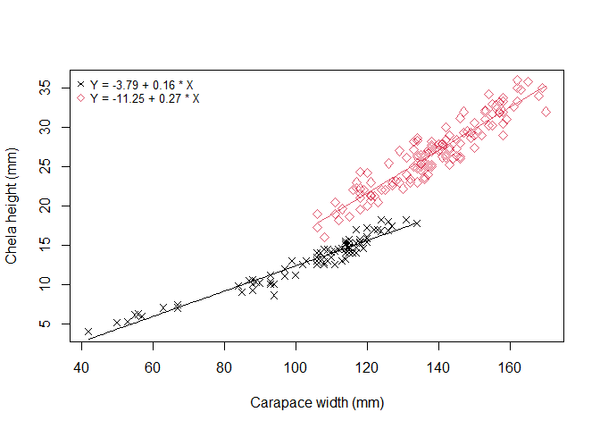

```r
plot(
  classify_data,
  xlab = "Carapace width (mm)",
  ylab = "Chela height (mm)"
)
```

The graphic can be customized using colors, point symbols, line types, and point size.

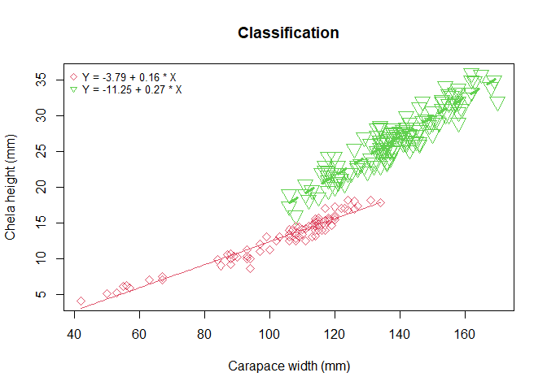

```r
plot(
  classify_data,
  xlab = "Carapace width (mm)",
  ylab = "Chela height (mm)",
  col = c(2, 3),
  pch = c(5, 6),
  lty_lines = c(1, 2),
  lwd_lines = c(1, 3),
  cex = c(1, 2),
  main = "Classification"
)
```

## 1.3 ggplot2-style plot for classified data

A `ggplot2` style can be obtained with `gg_style = TRUE`.

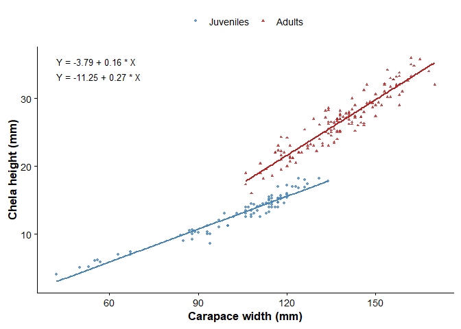

```r
plot(
  classify_data,
  xlab = "Carapace width (mm)",
  ylab = "Chela height (mm)",
  col = c("steelblue", "firebrick"),
  pch = c(16, 17),
  gg_style = TRUE
)
```

Because the function returns a `ggplot` object when `gg_style = TRUE`, the plot can be further modified.

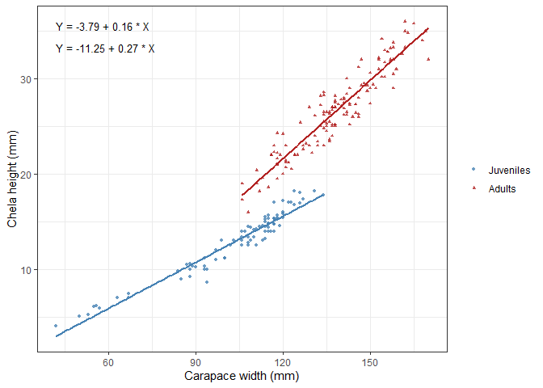

```r
p_classify <- plot(
  classify_data,
  xlab = "Carapace width (mm)",
  ylab = "Chela height (mm)",
  col = c("steelblue", "firebrick"),
  pch = c(16, 17),
  gg_style = TRUE
)

p_classify + ggplot2::theme_bw()
```

# 2. Estimation of size at morphometric maturity

After individuals are classified, size at morphometric maturity can be estimated using `morph_mature()`.

The model is based on a logistic function:

$$P_{CS} = \frac{1}{1 + e^{-(\hat{\beta}_{0} + \hat{\beta}_{1}X)}}$$

where $P_{CS}$ is the probability of being mature at length $X$.

The size at 50% maturity is calculated as:

$$L_{50} = -\frac{\hat{\beta}_{0}}{\hat{\beta}_{1}}$$

The argument `method` defines the model type:

- `method = "fq"` uses frequentist logistic regression;
- `method = "bayes"` uses Bayesian logistic regression.

For vignette purposes, we use a relatively small number of iterations so that the document compiles quickly.

```r
set.seed(123)

my_morph_fq <- morph_mature(
  classify_data,
  method = "fq",
  niter = 200
)

print(my_morph_fq)
```

```
#> formula: Y = 1/1+exp-(A + B*X)
#>     Original Bootstrap (Median)
#> A   -20.753  -21.086
#> B   0.1748   0.1762
#> L50 118.7237 118.6442
#> R2  0.7111   -
```

```r
my_morph_bayes <- morph_mature(
  classify_data,
  method = "bayes",
  niter = 200
)

print(my_morph_bayes)
```

```
#> formula: Y = 1/1+exp-(A + B*X)
#>     Bootstrap (Median)
#> A             -20.3108
#> B               0.1724
#> L50           118.3878
#> R2              0.7111
```

## 2.1 Base graphics plot for morphometric maturity

By default, `plot.morphMat()` uses base R graphics. It produces histograms for the model parameters and the maturity ogive.

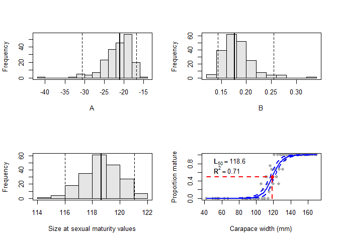

```
#> Size at morphometric maturity = 118.6
#> Confidence intervals = 116 - 121
#> Rsquare = 0.71

par(oldpar)
```

```r
oldpar <- par(no.readonly = TRUE)
par(mfrow = c(2, 2))

plot(
  my_morph_fq,
  xlab = "Carapace width (mm)",
  ylab = "Proportion mature",
  col = c("blue", "red")
)
```

To plot only the maturity ogive, use `onlyOgive = TRUE`.

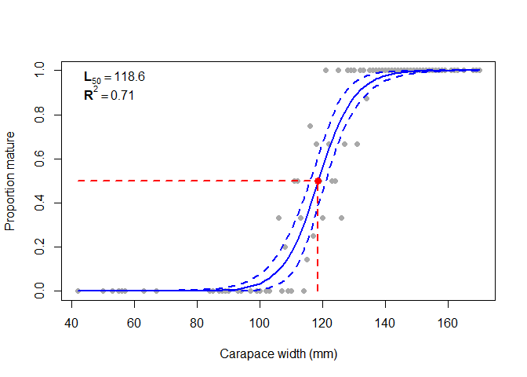

```
#> Size at morphometric maturity = 118.6
#> Confidence intervals = 116 - 121
#> Rsquare = 0.71
```

```r
plot(
  my_morph_fq,
  xlab = "Carapace width (mm)",
  ylab = "Proportion mature",
  col = c("blue", "red"),
  onlyOgive = TRUE
)
```

## 2.2 ggplot2-style plots for morphometric maturity

A `ggplot2` maturity ogive can be obtained using `gg_style = TRUE`.

```
#> Size at morphometric maturity = 118.6
#> Confidence intervals = 116 - 121
#> Rsquare = 0.71
```

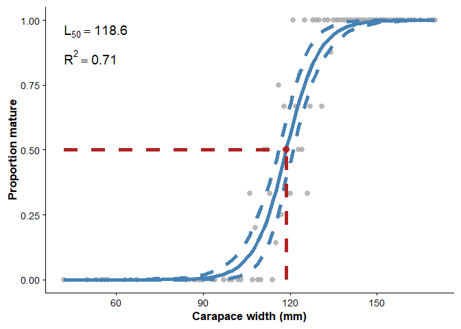

```r
plot(
  my_morph_fq,
  xlab = "Carapace width (mm)",
  ylab = "Proportion mature",
  col = c("steelblue", "firebrick"),
  onlyOgive = TRUE,
  gg_style = TRUE
)
```

When `onlyOgive = FALSE` and `gg_style = TRUE`, the function returns a list of independent `ggplot` objects.

```r
p_morph <- plot(
  my_morph_fq,
  xlab = "Carapace width (mm)",
  ylab = "Proportion mature",
  col = c("steelblue", "firebrick"),
  gg_style = TRUE
)
```

```
#> Size at morphometric maturity = 118.6
#> Confidence intervals = 116 - 121
#> Rsquare = 0.71
```

```r
names(p_morph)
```

```
#> [1] "A"     "B"     "L50"   "ogive"
```

The individual plots can then be displayed separately.

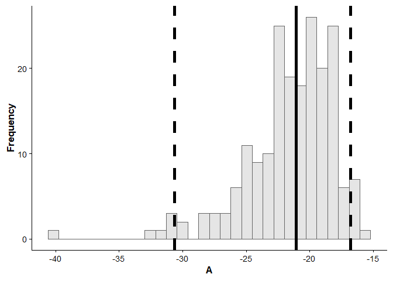

```r
p_morph$A
```

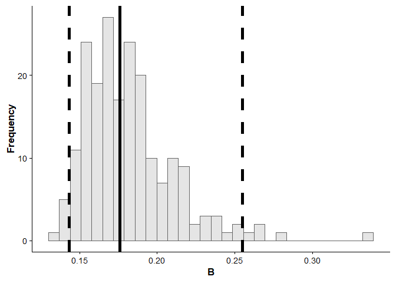

```r
p_morph$B
```

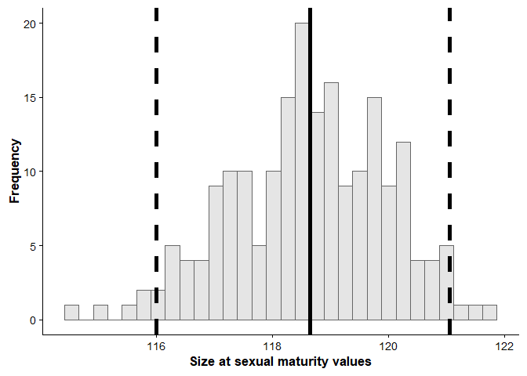

```r
p_morph$L50
```

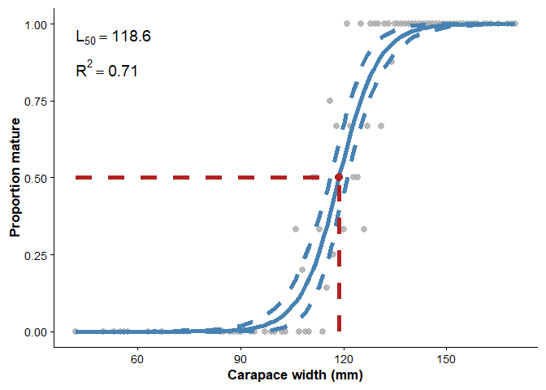

```r
p_morph$ogive
```

The returned plots can also be modified using standard `ggplot2` syntax.

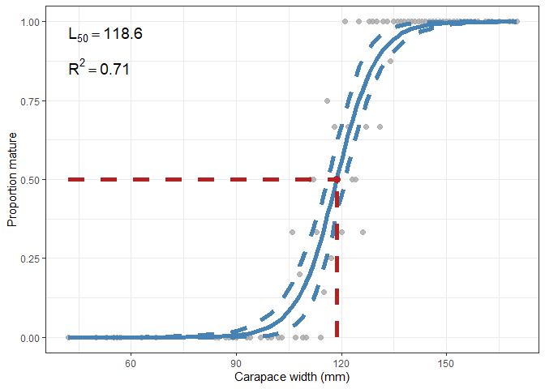

```r
p_morph$ogive +
  ggplot2::theme_bw()
```

# 3. Size at gonadal maturity

Gonadal maturity is estimated using a maturity stage variable and an allometric variable such as total length.

In this example, we use the `matFish` dataset.

```r
data(matFish)

head(matFish)
```

```
#>   total_length stage_mat
#> 1           12         I
#> 2           12         I
#> 3           13         I
#> 4           14         I
#> 5           14         I
#> 6           14         I
```

The dataset contains:

- `total_length`: total length in cm;
- `stage_mat`: gonadal maturation stage.

In this example, stage `I` is considered immature, whereas stages `II`, `III`, and `IV` are considered mature.

## 3.1 Estimation of size at gonadal maturity

The function `gonad_mature()` requires:

- `varNames`: the length variable and the maturity stage variable;
- `immName`: the immature stage or stages;
- `matName`: the mature stage or stages;
- `method`: the logistic regression approach;
- `niter`: the number of bootstrap or Bayesian iterations.

```r
set.seed(123)

my_gonad_fq <- gonad_mature(
  matFish,
  varNames = c("total_length", "stage_mat"),
  immName = "I",
  matName = c("II", "III", "IV"),
  method = "fq",
  niter = 200
)

print(my_gonad_fq)
```

```
#> formula: Y = 1/[1+exp-(A + B*X)]
#>     Original Bootstrap (Median)
#> A   -8.6047  -8.6497
#> B   0.356    0.3578
#> L50 24.1694  24.1841
#> R2  0.5595   -
```

```r
my_gonad_bayes <- gonad_mature(
  matFish,
  varNames = c("total_length", "stage_mat"),
  immName = "I",
  matName = c("II", "III", "IV"),
  method = "bayes",
  niter = 200
)

print(my_gonad_bayes)
```

```
#> formula: Y = 1/[1+exp-(A + B*X)]
#>     Bootstrap (Median)
#> A              -8.6026
#> B               0.3565
#> L50            24.1457
#> R2              0.5595
```

## 3.2 Base graphics plot for gonadal maturity

By default, `plot.gonadMat()` uses base R graphics.

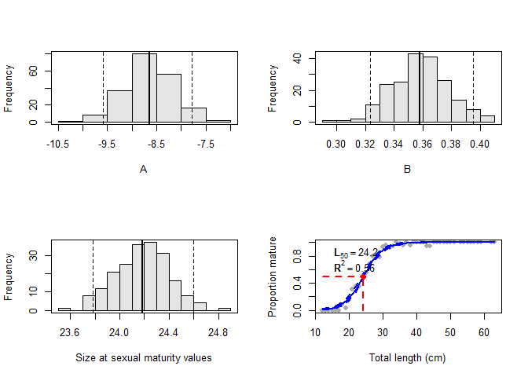

```
#> Size at gonadal maturity = 24.2
#> Confidence intervals = 23.8 - 24.6
#> Rsquare = 0.56

par(oldpar)
```

```r
oldpar <- par(no.readonly = TRUE)
par(mfrow = c(2, 2))

plot(
  my_gonad_fq,
  xlab = "Total length (cm)",
  ylab = "Proportion mature",
  col = c("blue", "red")
)
```

To plot only the maturity ogive, use `onlyOgive = TRUE`.

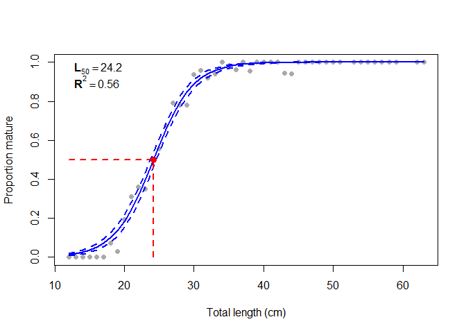

```
#> Size at gonadal maturity = 24.2
#> Confidence intervals = 23.8 - 24.6
#> Rsquare = 0.56
```

```r
plot(
  my_gonad_fq,
  xlab = "Total length (cm)",
  ylab = "Proportion mature",
  col = c("blue", "red"),
  onlyOgive = TRUE
)
```

The legend position can be modified with `legendPosition`.

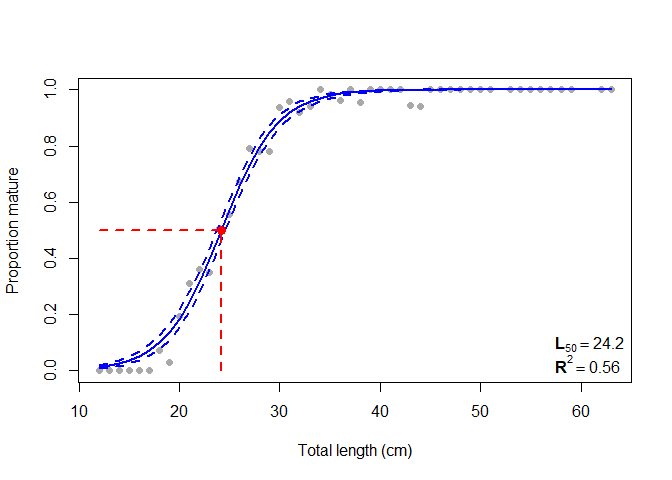

```
#> Size at gonadal maturity = 24.2
#> Confidence intervals = 23.8 - 24.6
#> Rsquare = 0.56
```

```r
plot(
  my_gonad_fq,
  xlab = "Total length (cm)",
  ylab = "Proportion mature",
  col = c("blue", "red"),
  onlyOgive = TRUE,
  legendPosition = "bottomright"
)
```

The legend can also be removed.

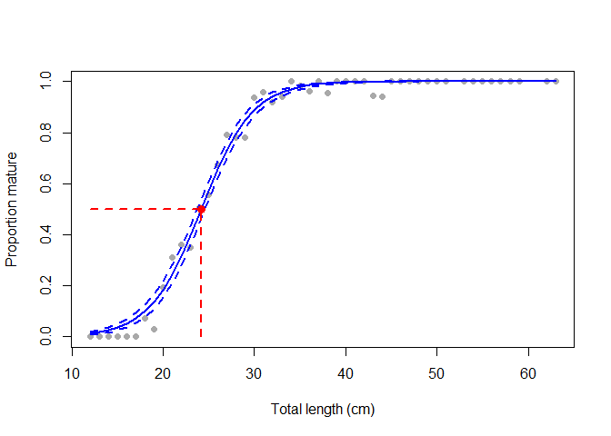

```
#> Size at gonadal maturity = 24.2
#> Confidence intervals = 23.8 - 24.6
#> Rsquare = 0.56
```

```r
plot(
  my_gonad_fq,
  xlab = "Total length (cm)",
  ylab = "Proportion mature",
  col = c("blue", "red"),
  onlyOgive = TRUE,
  showLegend = FALSE
)
```

## 3.3 ggplot2-style plots for gonadal maturity

A `ggplot2` maturity ogive can be obtained using `gg_style = TRUE`.

```
#> Size at gonadal maturity = 24.2
#> Confidence intervals = 23.8 - 24.6
#> Rsquare = 0.56
```

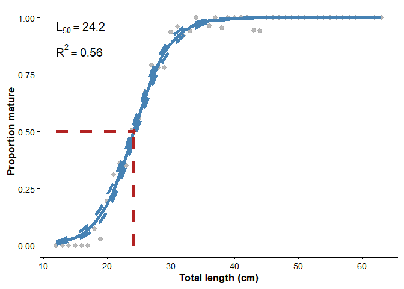

```r
plot(
  my_gonad_fq,
  xlab = "Total length (cm)",
  ylab = "Proportion mature",
  col = c("steelblue", "firebrick"),
  onlyOgive = TRUE,
  gg_style = TRUE
)
```

The position of the $L_{50}$ and $R^2$ labels can also be changed.

```
#> Size at gonadal maturity = 24.2
#> Confidence intervals = 23.8 - 24.6
#> Rsquare = 0.56
```

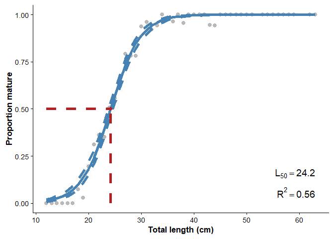

```r
plot(
  my_gonad_fq,
  xlab = "Total length (cm)",
  ylab = "Proportion mature",
  col = c("steelblue", "firebrick"),
  onlyOgive = TRUE,
  gg_style = TRUE,
  legendPosition = "bottomright"
)
```

When `onlyOgive = FALSE` and `gg_style = TRUE`, the function returns a list of independent `ggplot` objects.

```r
p_gonad <- plot(
  my_gonad_fq,
  xlab = "Total length (cm)",
  ylab = "Proportion mature",
  col = c("steelblue", "firebrick"),
  gg_style = TRUE
)
```

```
#> Size at gonadal maturity = 24.2
#> Confidence intervals = 23.8 - 24.6
#> Rsquare = 0.56
```

```r
names(p_gonad)
```

```
#> [1] "A"     "B"     "L50"   "ogive"
```

The individual plots can be displayed separately.

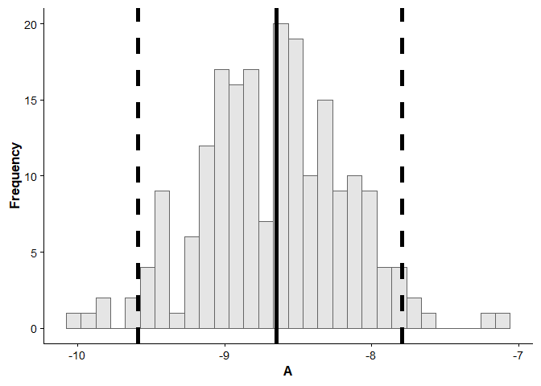

```r
p_gonad$A
```

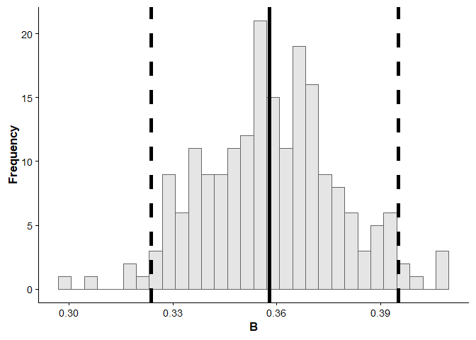

```r
p_gonad$B
```

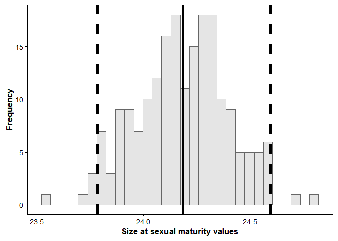

```r
p_gonad$L50
```

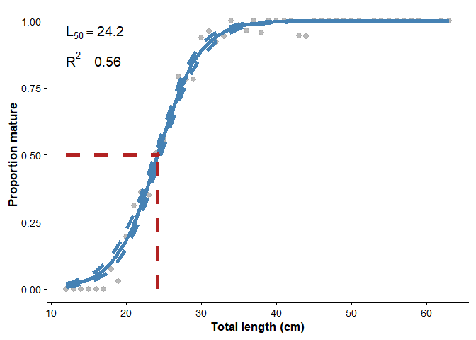

```r
p_gonad$ogive
```

The returned plots can be customized using `ggplot2`.

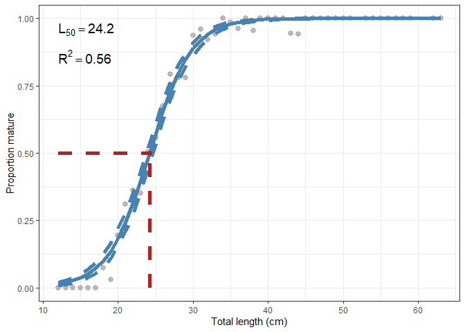

```r
p_gonad$ogive +
  ggplot2::theme_bw()
```

# References

Agostinho, C. S. (2000). Use of otoliths to estimate size at sexual maturity in fish. *Brazilian Archives of Biology and Technology*, 43(4).

Corgos, A. and Freire, J. (2006). Morphometric and gonad maturity in the spider crab *Maja brachydactyla*: a comparison of methods for estimating size at maturity in species with determinate growth. *ICES Journal of Marine Science*, 63(5), 851-859.

Roa, R., Ernst, B. and Tapia, F. (1999). Estimation of size at sexual maturity: an evaluation of analytical and resampling procedures. *Fishery Bulletin*, 97(3), 570-580.

Somerton, D. A. (1980). A computer technique for estimating the size of sexual maturity in crabs. *Canadian Journal of Fisheries and Aquatic Sciences*, 37(10), 1488-1494.